# RNA-seq Analysis in R

Annotation and Visualisation of RNA-seq results

Stephane Ballereau, Mark Dunning, Abbi Edwards, Oscar Rueda, Ashley Sawle

Last modified: 30 Aug 2018

```r
library(biomaRt)
library(DESeq2)
library(tidyverse)
```

Before starting this section, we will make sure we have all the relevant objects from the Differential Expression analysis.

```r
load("Robjects/DE.RData")
```

# Overview

- Getting annotation
- Visualising DE results
- Retrieving gene models
- Exporting browser tracks

# Adding annotation to the DESeq2 results

We have a list of significantly differentially expressed genes, but the only annotation we can see is the Ensembl Gene ID, which is not very informative.

There are a number of ways to add annotation. One method is to do this using the *org.Mm.eg.db* package. This package is one of several *organism-level* packages which are re-built every 6 months. These packages are listed on the [annotation section](http://bioconductor.org/packages/release/BiocViews.html#___AnnotationData) of the Bioconductor, and are installed in the same way as regular Bioconductor packages.

An alternative approach is to use `biomaRt`, an interface to the [BioMart](http://www.biomart.org/) resource. This is the method we will use today.

## Select BioMart database and dataset

The first step is to select the Biomart database we are going to access and which data set we are going to use.

```r
# view the available databases
listMarts()
```

```
##                biomart               version
## 1 ENSEMBL_MART_ENSEMBL      Ensembl Genes 93
## 2   ENSEMBL_MART_MOUSE      Mouse strains 93
## 3     ENSEMBL_MART_SNP  Ensembl Variation 93
## 4 ENSEMBL_MART_FUNCGEN Ensembl Regulation 93
```

```r
## set up connection to ensembl database
ensembl=useMart("ENSEMBL_MART_ENSEMBL")

# list the available datasets (species)
listDatasets(ensembl) %>%
    filter(str_detect(description, "Mouse"))
```

```
##                  dataset                  description   version
## 1  mmurinus_gene_ensembl Mouse Lemur genes (Mmur_3.0)  Mmur_3.0
## 2 mmusculus_gene_ensembl      Mouse genes (GRCm38.p6) GRCm38.p6
```

```r
# specify a data set to use
ensembl = useDataset("mmusculus_gene_ensembl", mart=ensembl)
```

## Query the database

Now we need to set up a query. For this we need to specify three things:

1. What type of information we are going to search the dataset on - called **filters**. In our case this is Ensembl Gene IDs
2. A vector of the **values** for our filter - the Ensembl Gene IDs from our DE results table
3. What columns (**attributes**) of the dataset we want returned.

Returning data from Biomart can take time, so it’s always a good idea to test your query on a small list of values first to make sure it is doing what you want. We’ll just use the first 1000 genes for now.

```r
# check the available "filters" - things you can filter for
listFilters(ensembl) %>%
    filter(str_detect(name, "ensembl"))
```

```
##                                   name
## 1        with_clone_based_ensembl_gene
## 2  with_clone_based_ensembl_transcript
## 3                      ensembl_gene_id
## 4              ensembl_gene_id_version
## 5                ensembl_transcript_id
## 6        ensembl_transcript_id_version
## 7                   ensembl_peptide_id
## 8           ensembl_peptide_id_version
## 9                      ensembl_exon_id
## 10            clone_based_ensembl_gene
## 11      clone_based_ensembl_transcript
##                                                         description
## 1                             With Clone-based (Ensembl) gene ID(s)
## 2                       With Clone-based (Ensembl) transcript ID(s)
## 3                       Gene stable ID(s) [e.g. ENSMUSG00000000001]
## 4        Gene stable ID(s) with version [e.g. ENSMUSG00000000001.4]
## 5                 Transcript stable ID(s) [e.g. ENSMUST00000000001]
## 6  Transcript stable ID(s) with version [e.g. ENSMUST00000000001.4]
## 7                    Protein stable ID(s) [e.g. ENSMUSP00000000001]
## 8     Protein stable ID(s) with version [e.g. ENSMUSP00000000001.4]
## 9                              Exon ID(s) [e.g. ENSMUSE00000097910]
## 10               Clone-based (Ensembl) gene ID(s) [e.g. AC034116.1]
## 11     Clone-based (Ensembl) transcript ID(s) [e.g. AC034116.1-201]
```

```r
# Set the filter type and values
filterType <- "ensembl_gene_id"
filterValues <- rownames(resLvV)[1:1000]

# check the available "attributes" - things you can retreive
listAttributes(ensembl) %>%
    head(20)
```

```
##                             name
## 1                ensembl_gene_id
## 2        ensembl_gene_id_version
## 3          ensembl_transcript_id
## 4  ensembl_transcript_id_version
## 5             ensembl_peptide_id
## 6     ensembl_peptide_id_version
## 7                ensembl_exon_id
## 8                    description
## 9                chromosome_name
## 10                start_position
## 11                  end_position
## 12                        strand
## 13                          band
## 14              transcript_start
```

[output cut: 27 more lines]

```r
# Set the list of attributes
attributeNames <- c('ensembl_gene_id', 'entrezgene', 'external_gene_name')

# run the query
annot <- getBM(attributes=attributeNames,
               filters = filterType,
               values = filterValues,
               mart = ensembl)
```

### One-to-many relationships

Let’s inspect the annotation.

```r
head(annot)
```

```
##      ensembl_gene_id entrezgene external_gene_name
## 1 ENSMUSG00000001138      94218              Cnnm3
## 2 ENSMUSG00000001143     214895             Lman2l
## 3 ENSMUSG00000002459      58175              Rgs20
## 4 ENSMUSG00000002881      17936               Nab1
## 5 ENSMUSG00000003134      54610             Tbc1d8
## 6 ENSMUSG00000003135      52846             Cnot11
```

```r
dim(annot) # why are there more than 1000 rows?
```

```
## [1] 1001    3
```

```r
length(unique(annot$ensembl_gene_id)) # why are there less than 1000 Gene ids?
```

```
## [1] 999
```

```r
isDup <- duplicated(annot$ensembl_gene_id)
dup <- annot$ensembl_gene_id[isDup]
annot[annot$ensembl_gene_id%in%dup,]
```

```
##        ensembl_gene_id entrezgene external_gene_name
## 483 ENSMUSG00000044783     212427              Hjurp
## 484 ENSMUSG00000044783     381280              Hjurp
## 867 ENSMUSG00000070645      19701               Ren1
## 868 ENSMUSG00000070645      19702               Ren1
```

There are a couple of genes that have multiple entries in the retrieved annotation. This is becaues there are multiple Entrez IDs for a single Ensembl gene. These one-to-many relationships come up frequently in genomic databases, it is important to be aware of them and check when necessary.

We will need to do a little work before adding the annotation to out results table. We could decide to discard one or both of the Entrez ID mappings, or we could concatenate the Entrez IDs so that we don’t lose information.

## Retrieve full annotation

### Challenge 1

> That was just 1000 genes. We need annotations for the entire results table. Also, there may be some other interesting columns in BioMart that we wish to retrieve.
> 1. Search the attributes and add the following to our list of attributes:
>    1. The gene description
>    2. The gene biotype
> 2. Query BioMart using all of the genes in our results table (`resLvV`)
> 3. How many Ensembl genes have multipe Entrez IDs associated with them?
> 4. How many Ensembl genes in `resLvV` don’t have any annotation? Why is this?

### Add annotation to the results table

We can now add the annotation to the results table and then save the results using the `write_tsv` function, which writes the results out to a tab separated file. To save time we have created an annotation table in which we have modified the cumbersome Biomart column names, added median transcript length (we’ll need this in a later session), and dealt with the one-to-many issues for Entrez IDs.

```r
load("Robjects/Ensembl_annotations.RData")
colnames(ensemblAnnot)
```

```
##  [1] "GeneID"         "Entrez"         "Symbol"         "Description"
##  [5] "Biotype"        "Chr"            "Start"          "End"
##  [9] "Strand"         "medianTxLength"
```

```r
annotLvV <- as.data.frame(resLvV) %>%
    rownames_to_column("GeneID") %>%
    left_join(ensemblAnnot, "GeneID") %>%
    rename(logFC=log2FoldChange, FDR=padj)
```

```r
write_tsv(annotLvV, "data/VirginVsLactating_Results_Annotated.txt")
```

# Visualisation

`DESeq2` provides a functon called `lfcShrink` that shrinks log-Fold Change (LFC) estimates towards zero using and empirical Bayes procedure. The reason for doing this is that there is high variance in the LFC estimates when counts are low and this results in lowly expressed genes appearing to be show greater differences between groups that highly expressed genes. The `lfcShrink` method compensates for this and allows better visualisation and ranking of genes. We will use it for our visualisations of the data.

```r
ddsShrink <- lfcShrink(ddsObj, coef="Status_lactate_vs_virgin")
shrinkLvV <- as.data.frame(ddsShrink) %>%
    rownames_to_column("GeneID") %>%
    left_join(ensemblAnnot, "GeneID") %>%
    rename(logFC=log2FoldChange, FDR=padj)
```

## P-value histogram

A quick and easy “sanity check” for our DE results is to generate a p-value histogram. What we should see is a high bar in the `0 - 0.05` and then a roughly uniform tail to the right of this. There is a nice explanation of other possible patterns in the histogram and what to when you see them in [this post](http://varianceexplained.org/statistics/interpreting-pvalue-histogram/).

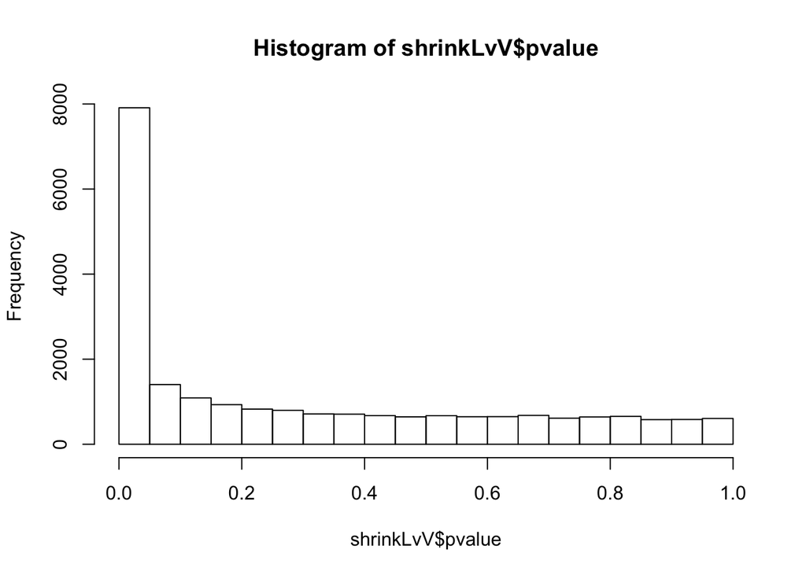

```r
hist(shrinkLvV$pvalue)
```

## MA plots

MA plots are a common way to visualize the results of a differential analysis. We met them briefly towards the end of Session 2. This plot shows the log-Fold Change for each gene against its average expression across all samples in the two conditions being contrasted.

`DESeq2` has a handy function for plotting this…

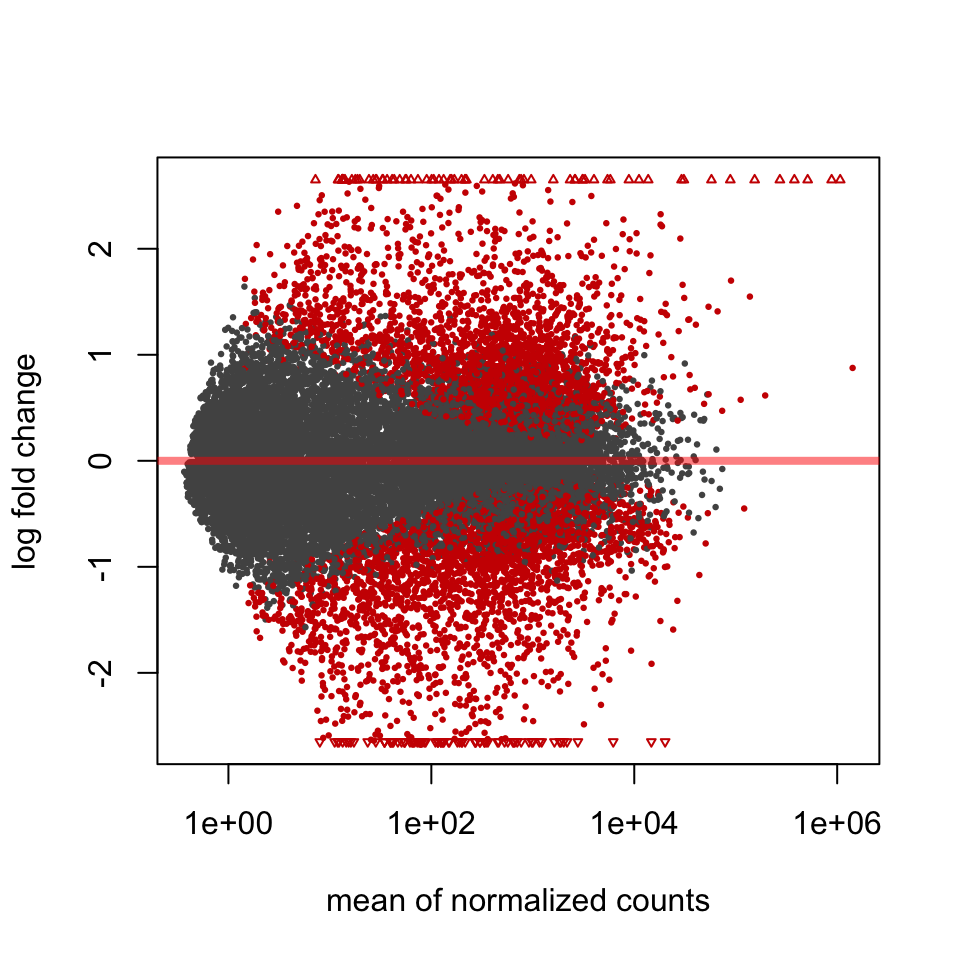

```r
plotMA(ddsShrink, alpha=0.05)
```

### A Brief Introduction to `ggplot2`

The [`ggplot2`](http://ggplot2.tidyverse.org/) package has emerged as an attractive alternative to the traditional plots provided by base R. A full overview of all capabilities of the package is available from the [cheatsheet](https://www.rstudio.com/wp-content/uploads/2015/03/ggplot2-cheatsheet.pdf).

In brief:-

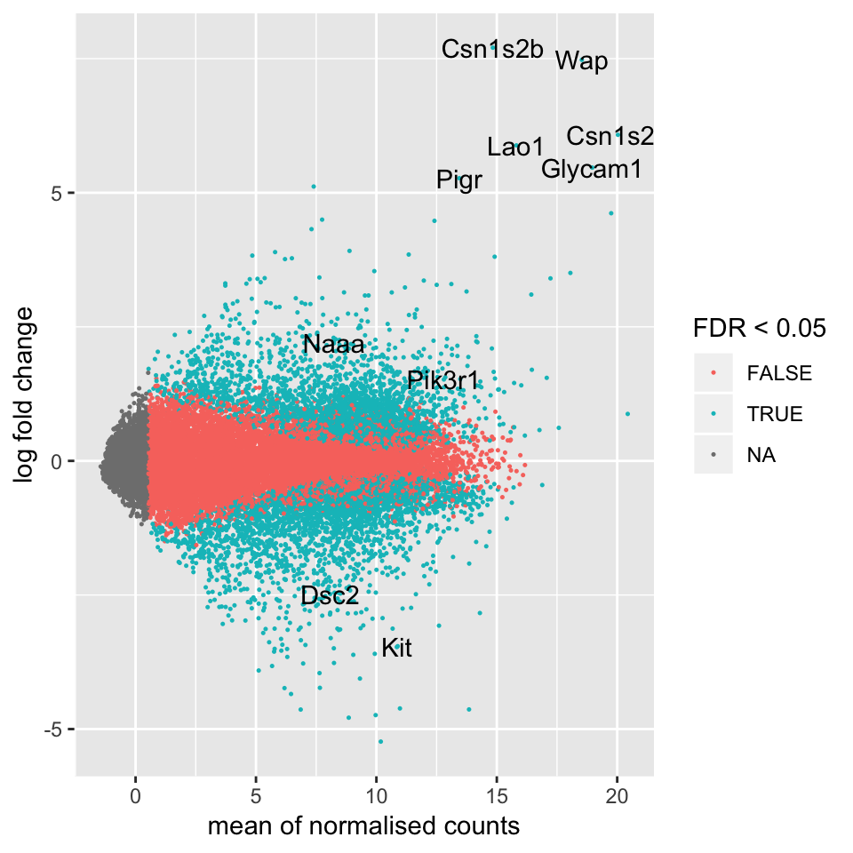

```r
# add a column with the names of only the top 10 genes
cutoff <- sort(shrinkLvV$pvalue)[10]
shrinkLvV <- shrinkLvV %>%
    mutate(TopGeneLabel=ifelse(pvalue<=cutoff, Symbol, ""))

ggplot(shrinkLvV, aes(x = log2(baseMean), y=logFC)) +
    geom_point(aes(colour=FDR < 0.05), pch=20, size=0.5) +
    geom_text(aes(label=TopGeneLabel)) +
    labs(x="mean of normalised counts", y="log fold change")
```

## Volcano plot

Another common visualisation is the *volcano plot* which displays a measure of significance on the y-axis and fold-change on the x-axis.

### Challenge 2

> Use the log2 fold change (`logFC`) on the x-axis, and use `-log10(FDR)` on the y-axis. (This >`-log10` transformation is commonly used for p-values as it means that more significant genes have a >higher scale)
> 1. Remove the genes that we excluded by the independent filtering process of DESeq2
> 2. Create a column of -log10(FDR) values
> 3. Create a plot with points coloured by if FDR < 0.05
> 4. Limit the values at the top in order to see the lower portion more clearly.

An example of what your plot should look like:

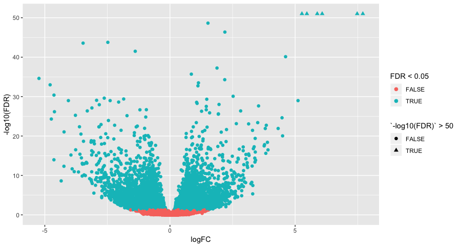

## Strip chart for gene expression

Before following up on the DE genes with further lab work, a recommended *sanity check* is to have a look at the expression levels of the individual samples for the genes of interest. We can quickly look at grouped expression by using `plotCounts` function of `DESeq2` to retrieve the normalised expression values from the `ddsObj` object and then plotting with `ggplot2`.

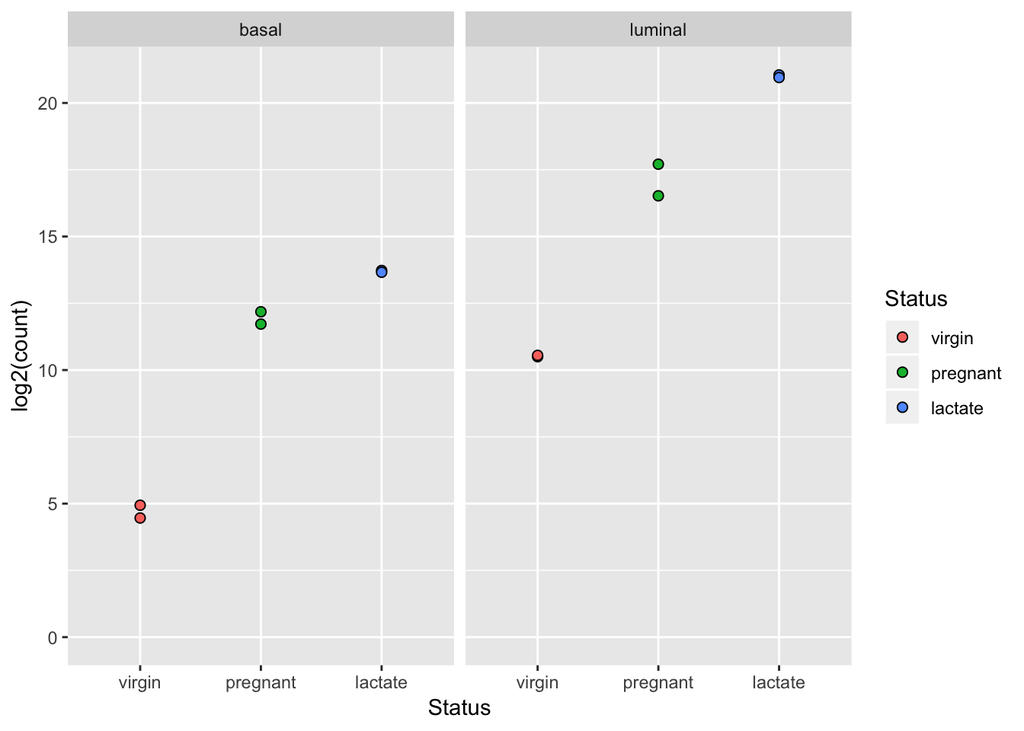

```r
# Let's look at the most significantly differentially expressed gene
topgene <- filter(shrinkLvV, Symbol=="Wap")
geneID <- topgene$GeneID

plotCounts(ddsObj, gene = geneID, intgroup = c("CellType", "Status"),
           returnData = T) %>%
    ggplot(aes(x=Status, y=log2(count))) +
      geom_point(aes(fill=Status), pch=21, size=2) +
      facet_wrap(~CellType) +
      expand_limits(y=0)
```

### Interactive StripChart with Glimma

An interactive version of the volcano plot above that includes the raw per sample values in a separate panel is possible via the `glXYPlot` function in the *Glimma* package.

```r
save(annotLvV, shrinkLvV, file="results/Annotated_Results_LvV.RData")
```

```r
library(Glimma)

group <- str_remove_all(sampleinfo$Group, "[aeiou]")

de <- as.integer(filtTab$FDR <= 0.05)

normCounts <- log2(counts(ddsObj))
filtCounts <- normCounts[filtTab$GeneID,]

glXYPlot(
  x = filtTab$logFC,
  y = -log10(filtTab$FDR),
  xlab = "logFC",
  ylab = "FDR",
  main = "Lactating v Virgin",
  counts = filtCounts,
  groups = group,
  status = de,
  anno = filtTab[, c("GeneID", "Symbol", "Description")],
  folder = "volcano"
)
```

This function creates an html page (./volcano/XY-Plot.html) with a volcano plot on the left and a plot showing the log-CPM per sample for a selected gene on the right. A search bar is available to search for genes of interest.